# Projet_RDSM | Données de nutrition pour bébés et enfants

Abel Koors || Guillaume Souksava

# Introduction

## ACP non normée

### a) Pourquoi d’après-vous faut-il faire une ACP normeée ?

Ecarts-type pour les différentes variables :

```r
sdn <- function(v){ sqrt( mean((v-mean(v))^2))}
apply(plats, 2, sdn)
```

```
##    VitA_mcg    VitB6_mg  VitB12_mcg     VitC_mg     VitE_mg   VitB9_mcg
## 169.1688129   0.3390514   0.5907248  25.9598000   2.2522647  45.9009463
##    VitB3_mg    VitB2_mg    VitB1_mg       Fat_g     Fiber_g     Sugar_g
##   5.1456782   0.5818006   0.5404869   8.4343761   1.4876212  16.9496099
##   Protein_g
##   4.7151407
```

D’après les écarts-type calculés, on remarque que la variable VitA_mg a un écart type bien supérieur à celui des autres variables (169.17). Ainsi, cette variable a un poids bien plus important que les autres et, si l’on décidait d’éffectuer une ACP non normée sur le jeu de données, l’hétérogénéité des variables entraînerait des problèmes d’échelle. De plus, certaines variables sont données en grammes et d’autres en miligrammes, faire une ACP non normée est alors moins adéquat ici.

### b) Appliquez une ACP non normeée : commentez la projection des variables et justifiez la position de la variable VitA_mcg.

*Projection des variables de l’ACP non normée sur la matrice de covariance :*

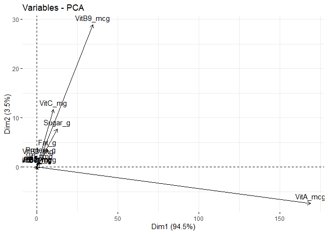

```r
pca.plats <- PCA(plats, scale.unit = FALSE,graph=FALSE)
fviz_pca_var(pca.plats)
```

Axe 1 :

D’après ce graphe, nous observons que le 1er axe est principalement expliqué par la variable VitA_mcg. Un individu avec une forte (resp. faible) coordonnée sur l’axe 1 serait riche (resp. pauvre) en Vitamine A.

Axe 2 :

L’axe 2, quant à lui, serait en grande partie expliqué par la variable VitB9_mcg. Un plat avec une forte (resp. faible) coordonnée sur l’axe 2 aurait alors une forte (resp. faible) concentration en Vitamine B. Globalement, les variables VitA_mcg et VitB9_mcg sont les variables avec les plus grands écarts-type. Ces 2 variables sont celles qui ont le plus de poids dans cette analyse non normée et explique respectivement les axes 1 et 2 (presque à elles seules).

*Coordonnées des variables de l’ACP non normée sur la matrice de covariance :*

```r
pca.plats$var$coord
```

```
##                   Dim.1      Dim.2        Dim.3        Dim.4         Dim.5
## VitA_mcg   169.00740144 -7.3750476  0.383440821 -0.212863439  0.0213632927
## VitB6_mg     0.06552230  0.1059035 -0.055576662  0.008437659  0.0721138756
## VitB12_mcg   0.39739219  0.1793396 -0.035917048  0.102729835  0.0914759443
## VitC_mg     10.25465616 11.6508974 20.744139610 -1.637123259 -0.0036889925
## VitE_mg      1.72400829  0.8833441 -0.056420649  0.230867468  0.3739933409
## VitB9_mcg   34.53786950 28.8765819 -8.775110130 -1.654400968 -0.6285571313
## VitB3_mg     0.74994948  1.8818610 -0.543256158 -0.732268676  4.3716071664
## VitB2_mg     0.08878752  0.2412568 -0.092225904 -0.049405776  0.4253233158
## VitB1_mg     0.04546288  0.1895733 -0.079385993 -0.055174539  0.4056673683
## Fat_g        6.72745689  3.6013213 -0.543164628  1.539350967  1.2175222903
## Fiber_g     -0.28495037  0.1622264 -0.001939457 -0.137973729  0.5995631462
## Sugar_g     12.60451277  7.6998426  2.550942266  7.877787360  0.0001783886
## Protein_g    2.52637356  2.1174033 -0.957962467  0.130178093  2.4119680212
```

Pour rejoindre ce que nous avons dit précedemment, les variables VitA_mcg et VitB9_mcg sont celles avec les plus grandes coordonnées sur les axes 1 et 2 respectvivement, résultat que nous retrouvons en s’intéressant aux contributions de ces variables pour l’axe 1 et 2.

*Contribution des variables de l’ACP non normée :*

```r
pca.plats$var$contrib
```

```
##                   Dim.1        Dim.2        Dim.3        Dim.4        Dim.5
## VitA_mcg   9.497162e+01  4.921322258 2.852086e-02 6.424038e-02 1.649713e-03
## VitB6_mg   1.427449e-05  0.001014782 5.991711e-04 1.009369e-04 1.879791e-02
## VitB12_mcg 5.250747e-04  0.002910079 2.502460e-04 1.496233e-02 3.024724e-02
## VitC_mg    3.496428e-01 12.282051344 8.347506e+01 3.799870e+00 4.919120e-05
## VitE_mg    9.882370e-03  0.070601187 6.175072e-04 7.556687e-02 5.055914e-01
## VitB9_mcg  3.966190e+00 75.447303174 1.493726e+01 3.880499e+00 1.428109e+00
## VitB3_mg   1.870021e-03  0.320425633 5.724996e-02 7.602333e-01 6.908029e+01
## VitB2_mg   2.621116e-05  0.005266368 1.649954e-03 3.460680e-03 6.538984e-01
## VitB1_mg   6.872207e-06  0.003251672 1.222514e-03 4.316020e-03 5.948563e-01
## Fat_g      1.504819e-01  1.173480534 5.723067e-02 3.359551e+00 5.358284e+00
## Fiber_g    2.699733e-04  0.002381196 7.296696e-07 2.698974e-02 1.299397e+00
## Sugar_g    5.282440e-01  5.364334435 1.262313e+00 8.798618e+01 1.150287e-07
## Protein_g  2.122157e-02  0.405657339 1.780176e-01 2.402602e-02 2.102883e+01
```

Nous avons vu que l’axe 1 conservait 94.5% de l’inertie globale. Le tableau des contributions des variables indique que la variable VitA_mcg explique 95% du premier axe et que VitB9_mcg explique 75% de l’axe 2. Les axes sont donc expliqué par les variables à fortes variances (écarts-type). L’ACP non normée n’est donc pas une bonne approche pour ce jeu de données.

# A/ Analyse uni- et bivariées

## 1° Analyse des variables

### a) Calcul des quantiles des variables numériques du jeu de données

```r
#moyennes et quantiles des variables numériques
apply(plats[c(1:13)], 2, mean)
```

```
##    VitA_mcg    VitB6_mg  VitB12_mcg     VitC_mg     VitE_mg   VitB9_mcg
## 109.7403315   0.1376740   0.3563536  18.9759669   1.3768232  32.0303867
##    VitB3_mg    VitB2_mg    VitB1_mg       Fat_g     Fiber_g     Sugar_g
##   2.6179834   0.2844420   0.2268950   5.5804420   0.8660221  12.6755249
##   Protein_g
##   4.1146685
```

```r
apply(plats[c(1:13)], 2, var)
```

```
##     VitA_mcg     VitB6_mg   VitB12_mcg      VitC_mg      VitE_mg    VitB9_mcg
## 2.869736e+04 1.152743e-01 3.499224e-01 6.757780e+02 5.086748e+00 2.112733e+03
##     VitB3_mg     VitB2_mg     VitB1_mg        Fat_g      Fiber_g      Sugar_g
## 2.655135e+01 3.394296e-01 2.929353e-01 7.133576e+01 2.219147e+00 2.880851e+02
##    Protein_g
## 2.229414e+01
```

```r
apply(plats[c(1:13)], 2, quantile, probs=c(0.1, 0.9))
```

```
##     VitA_mcg VitB6_mg VitB12_mcg VitC_mg VitE_mg VitB9_mcg VitB3_mg VitB2_mg
## 10%      0.0    0.024      0.000    0.30   0.000         2   0.1190     0.02
## 90%    454.7    0.310      1.474   58.48   4.995       131   5.4554     0.72
##     VitB1_mg Fat_g Fiber_g Sugar_g Protein_g
## 10%   0.0100   0.1    0.00   0.000       0.2
## 90%   0.4999  25.6    2.09  52.182      12.5
```

On remarque grâce à ces lignes de code que les moyennes, les variances et la répartition en quantiles diffèrent en fonction des variables. Ces résultats dénotent aussi de l’adéquation de réaliser une ACP normée.

### b) Matrice de corrélation

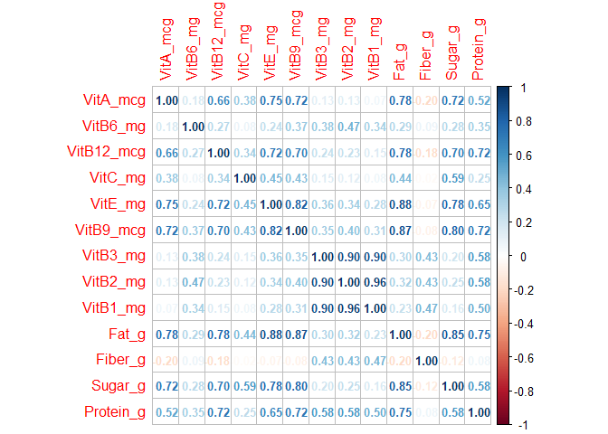

```r
corrplot(cor(plats[, 1:13]),method = "number", number.cex = 0.8, number.digits = 2)
```

D’après la matrice des corrélations, on observe que les variables correspondant à la concentration en vitamine B1, B2 et B3 sont fortement corrélés positivement entre elles (corrélations supérieures à 0.90).

Par ailleurs, on observe aussi une corrélation positive entre les variables vitamine A, B9, E et B12 (corrélations supérieures à 0,66).

Enfin, les variables nutritionnelles graisse, protéine et sucre sont positivement corrélées entre elles.

De plus, d’après la matrice des corrélations, la graisse, la composition en protéines et la sucrosité d’un plat sont positivement corrélées avec les compositions en vitamine A, B12, E et B9.

### c) Matrice des graphiques croisés

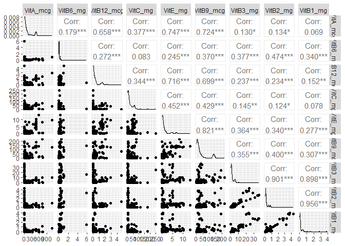

D’après la matrice des graphiques croisés, on remarque pour les variables VitB6, VitB12 et VitC que les points sont à des valeurs extrêmes. On supprime alors les plats ou les valeurs pour les variables VitB6, VitB12 et VitC sont extrêmes.

```r
quantile(boxplot.stats(plats$VitC_mg)$out, 0.75)
```

```
##   75%
## 113.1
```

```r
abC <- which(plats$VitC_mg > 113)

quantile(boxplot.stats(plats$VitB12_mcg)$out, 0.95)
```

```
##  95%
## 2.31
```

```r
abB12 <- which(plats$VitB12_mcg > 2.31)

quantile(boxplot.stats(plats$VitB6_mg)$out, 0.95)
```

```
##  95%
## 0.98
```

```r
abB6 <- which(plats$VitB6_mg > 0.98)

plats_sans_aberrantes <- plats[-c(abC, abB12, abB6),]

c(abC, abB6, abB12)
```

```
## [1]  16 105 358 146 291 312 216 312
```

### d) Découpage de la variable “sugar” et élaboration des boîtes à moustaches

Après avoir découpé la variable “sugar” en 3 catégories, on peut construire les boites à moustaches parallèles de VitC selon ces groupes d’aliments.

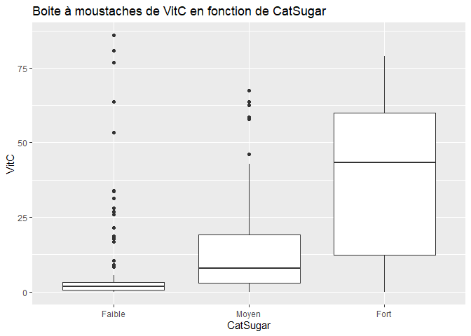

```r
#boites à moustaches parallèles
ggplot(plats_sans_aberrantes, aes(y=VitC_mg,x=Cat_Sugar)) +
  geom_boxplot() +
  labs(title="Boite à moustaches de VitC en fonction de CatSugar",
                x ="CatSugar", y = "VitC")
```

Ces boîtes à moustaches nous donnent des informations quant au lien entre les variable VitC et CatSugar. En effet, on remarque que plus le taux de sucre est élevé dans le plat, plus il sera composé de vitamine C. Alors on peut supposé que le taux de sucre d’un plat dépend de sa concentration en vitamine C.

# B/ ACP normée du jeu de données

### a) ACP normée

Bien que nous savons que l’Analyse en Composantes principales est sensible aux valeurs aberrantes, nous avons décidé de réaliser sur le jeu de données complet, puisqu’il n’est pas précisé d’utiliser le jeu de données sans valeurs extrêmes.

De plus, certains individus supprimés et considérés extrêmes faisaient référence à des questions de l’énoncé, nous les avons donc laissés.

Bien entendu, les résultats de l’ACP auraient été différents, mais les conclusions sur la proximité des individus et le lien entre les variables aurait été proche tout de même.

#### Valeurs propres

```r
pca.plats2 <-PCA(plats[,1:13], quanti.sup = c(10:13) , scale.unit = TRUE, graph = FALSE)
pca.plats2$eig
```

```
##        eigenvalue percentage of variance cumulative percentage of variance
## comp 1 4.31486191             47.9429101                          47.94291
## comp 2 2.27545397             25.2828219                          73.22573
## comp 3 0.82354105              9.1504561                          82.37619
## comp 4 0.69032682              7.6702980                          90.04649
## comp 5 0.34407313              3.8230348                          93.86952
## comp 6 0.23983514              2.6648349                          96.53436
## comp 7 0.17710217              1.9678019                          98.50216
## comp 8 0.10407700              1.1564111                          99.65857
## comp 9 0.03072882              0.3414314                         100.00000
```

Eboulis des valeurs propres :

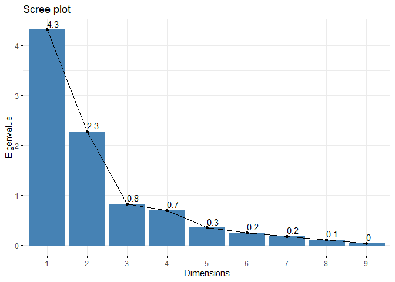

```r
fviz_eig(pca.plats2, choice = "eigenvalue", addlabels=TRUE)
```

En utilisant la méthode de Kaiser, on conserve 2 axes pour l’analyse, les 2 premières valeurs propres étant supérieurzs à 1. D’après le tableau des valeurs propres, ces deux axes expliqueraient 73.22% de l’inertie. On pourrait aussi garder le 3ème axe pour expliquer 82% de l’inertie totale, et ainsi dépasser les 75%.

#### Cercle de corrélation

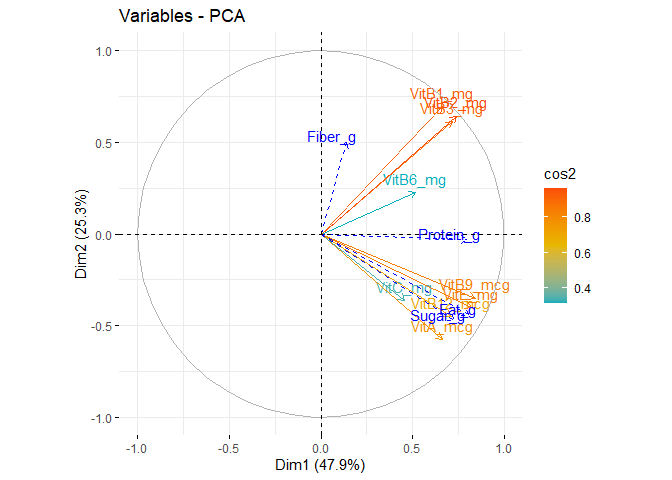

```r
fviz_pca_var(pca.plats2,axes = c(1,2), col.var = "cos2",
             gradient.cols = c("#00AFBB", "#E7B800", "#FC4E07"),)
```

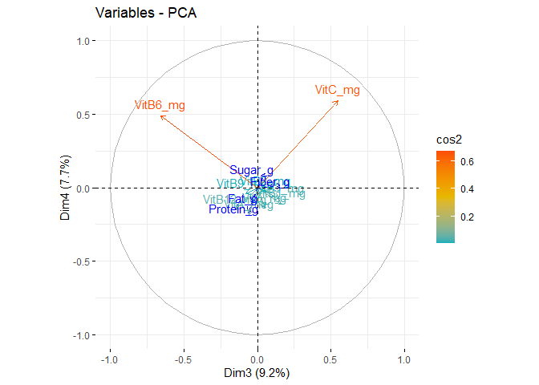

```r
fviz_pca_var(pca.plats2,axes = c(3,4), col.var = "cos2",
             gradient.cols = c("#00AFBB", "#E7B800", "#FC4E07"),)
```

```r
pca.plats2$var$coord
```

```
##                Dim.1      Dim.2       Dim.3       Dim.4       Dim.5
## VitA_mcg   0.6628021 -0.5756120 -0.05697080 -0.18273455 -0.28816096
## VitB6_mg   0.5161849  0.2254348 -0.65979046  0.49129106 -0.03760787
## VitB12_mcg 0.7112282 -0.4504108 -0.14876642 -0.14985776  0.48574692
## VitC_mg    0.4582526 -0.3625013  0.54912082  0.59398581  0.04073998
## VitE_mg    0.8227984 -0.4034181  0.05170494 -0.14083534 -0.07073035
## VitB9_mcg  0.8431645 -0.3502469 -0.07968362 -0.04224463 -0.12283310
## VitB3_mg   0.7174549  0.6141601  0.15268017 -0.07554062  0.03872798
## VitB2_mg   0.7408276  0.6427084  0.05460422 -0.02506684 -0.01127861
## VitB1_mg   0.6646631  0.6952274  0.16121746 -0.11107458 -0.01715840
```

Le cercle des corrélations nous donne de nombreuses informations quant au lien entre les variables entre elles mais surtout avec les composantes principales (les axes). Tout d’abord nous remarquons que les variables VitB1_mg, Vit_B2_mg, VitB3_mg, sont fortement corrélés, ce que nous avions déjà souligné avec la matrice de corrélation. De plus, les variables mésurant la composition en vitamine A, E, B9, B12 et en sucre sont fortement corréles, ce que nous avions remarqué avec la matrice de corrélation. Les variables VitB6 et VitC ne sont pas trés bien répresentées sur le plan (1,2) mais le sont très bien sur le plan (3,4).

*Axe 1 :*

Variables significativement positivement corrélées avec l’axe 1: les variables Fat_g, Protein_g, Sugar_g, VitB9_mcg, VitE_mg, VitB12_mcg et VitA_mcg. Ainsi, les plats ayant une forte (resp. faible) coordonnée sur l’axe 1 sont riches (resp. pauvres) en graisse, sucre, protéine, vitamine E, B9, 12 et A. Les coordonnées de ces variables sur l’axe 1 sont proches de 1 (proches du cercle), ainsi, elles sont bien représentées sur cet axe.

*Axe 2 :*

Variables significativement positivement corrélées avec l’axe 2: les variables Fiber_g, VitB1_mg, VitB2_mg et VitB3_mg Ainsi, les plats ayant une forte (resp. faible) coordonnée positive sur l’axe 2 sont riches (resp. pauvres) en fibre, vitamine B1, B2, B3.

*Axe 3 :*

L’axe 3 semble expliqué par les variables VitB6_mg et VitC_mg. Une coordonnée élevée (resp. faible) sur l’axe 3 sera représentative d’un plat riche (resp. pauvre) en vitamine C et pauvre (resp. riche) en vitamine B6.

*Axe 4 :*

En ce qui concerne l’axe 4, l’information est encore une fois portée par les variables VitB6_mg et VitC_mg, toutes les 2 positivement corrélées avec l’axe. Ainsi, une coordonnée positive sur l’axe 4 indiquera une forte composition en vitamine C et en vitamine B6

### b) Analyse des 20 individus les plus contribuants au premier plan factoriel

#### Contributions des individus

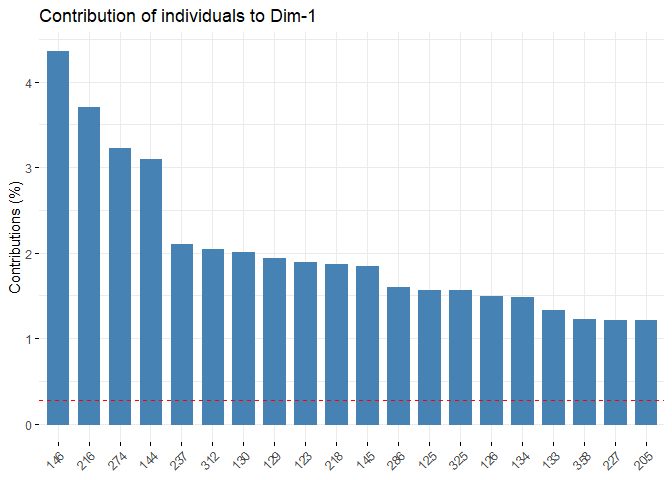

```r
fviz_contrib(pca.plats2,choice="ind",axes = 1, sortcontrib = "desc", top = 20)
```

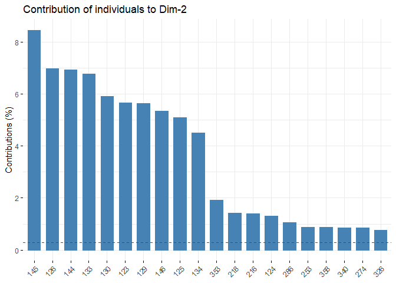

```r
fviz_contrib(pca.plats2,choice="ind",axes = 2, sortcontrib = "desc", top = 20)
```

Ces lignes de code nous donnent les 20 individus qui contribuent le plus à la construction des 2 axes.

### c) Analyse de quelques individus

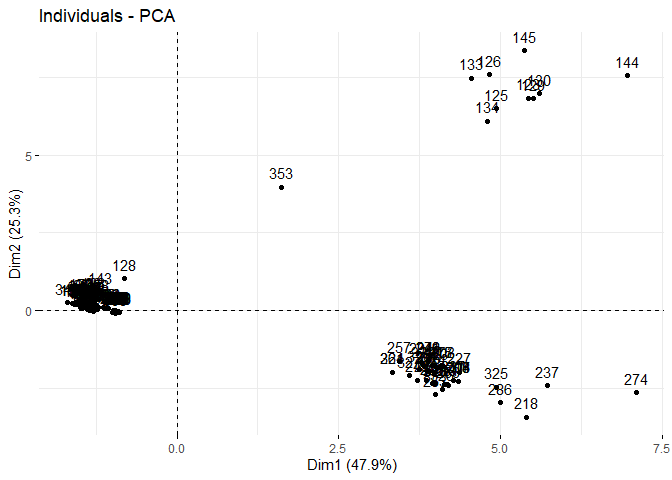

```r
fviz_pca_ind(pca.plats2,axes = c(1,2), select.ind = list(name = NULL, cos2 = 0.85, contrib = NULL))
```

Le plat 144 (décrit en tant que Babyfood_ cereal_ high protein_ with apple and orange_ dry) a des fortes coordonnées sur les 2 axes, il s’agit d’un repas très protéiné (le plus protéiné de la base de données) mais avec beaucoup de fibres (fruits) données par les fortes compositions en vitamines B1, B2 et B3.

Le plat 241 (alimentation en poudre de fer) a des coordonnées élevées sur l’axe 1 et très négatives sur l’axe 2. Il est le plas le plus gras de la base de données, il est pauvre en fibres et en vitamines B1, B2, B3 mais très riches en vitamines A, E, B9 et B12.

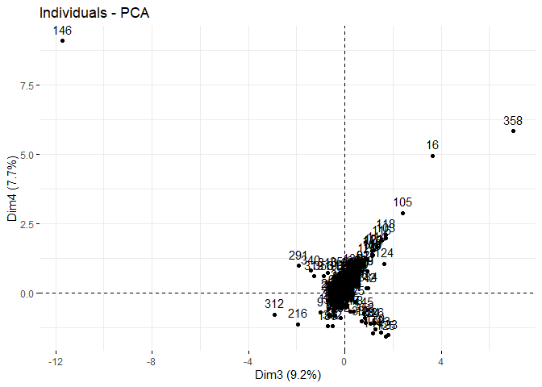

```r
fviz_pca_ind(pca.plats2,axes = c(3,4), select.ind = list(name = NULL, cos2 = NULL, contrib = NULL))
```

Sur le second plan factoriel, le plat 358 a de fortes coordonnées quelque soit l’axe. Cela se traduit par une très forte composition en vitamine C C (le plus fort dans la base de données). Sur l’axe 3, il est encore une fois très positif, synonyme d’une faible composition en vitamine B6.

### d) Comparaison des plats 218 et 216

```r
pca.plats2$ind$cos2[c(216, 218),]
```

```
##         Dim.1     Dim.2       Dim.3      Dim.4        Dim.5
## 216 0.7025480 0.1388678 0.045808843 0.01488900 0.0009682045
## 218 0.6079224 0.2442750 0.002969178 0.00877213 0.0119499813
```

Les 2 plats sont bien représentés sur le premier plan factoriel, nous pouvons alors les étudier et déduire des informations de leur position.

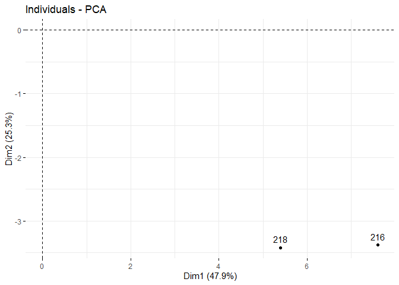

```r
fviz_pca_ind(pca.plats2,axes = c(1,2), select.ind = list(name = c(218, 216), cos2 = NULL, contrib = NULL))
```

Les plats 218 et 216 ont une forte coordonnée sur l’axe 1 et une coordonnée négative sur l’axe 2. En reprenant les cercle des corrélations et en observant les données initiales, on retrouve que les plats 218 et 216 ont une forte composition en graisse, sucre et protéine, tout comme en vitamine E, B9, A et B12. En effet, on peut souligner que les plats 216 et 144 sont les deux plats les plus riches en protéines de notre base de données.

Sur l’axe 2, les plats étudiés ont une faible coordonnée, synonyme d’une faible composition en vitamines B1, B2 et B3 et en fibres.

### e) Variance des abscisses des points (coordonnées des individus sur le premier axe)

Par définition de la variance :

```r
sum(pca.plats2$ind$coord[,1]**2)/362
```

```
## [1] 4.314862
```

En considérant la variance comme la norme au carrée de la première composante principale :

```r
N<-diag(1/362,nrow=362,ncol = 362)

t(pca.plats2$ind$coord[,1])%*%N%*%pca.plats2$ind$coord[,1]
```

```
##          [,1]
## [1,] 4.314862
```

On retrouve ici la valeur de la plus grande valeur propre 4.314862

```r
pca.plats2$eig[1,1]
```

```
## [1] 4.314862
```

# C/ Inactivation des plats les plus extrêmes

### a) Filtrage des données

```r
inactifs<-pca.plats2$ind$coord[,1] >3 & pca.plats2$ind$coord[,2]<0
inactifs <- as.vector(inactifs)
indices <- which(as.vector(inactifs)=="TRUE")
```

En filtrant les données, on trouve 43 individus à rendre inactifs (ou supplémentaires).

### b) ACP avec quelques plats en inactifs

```r
pca.plats22<-PCA(plats[1:13], quanti.sup = c(10:13),scale.unit = TRUE,graph = FALSE, ind.sup = indices)
pca.plats22$eig
```

```
##        eigenvalue percentage of variance cumulative percentage of variance
## comp 1 3.52320149             39.1466832                          39.14668
## comp 2 1.43205792             15.9117546                          55.05844
## comp 3 1.01513859             11.2793177                          66.33776
## comp 4 0.92061692             10.2290769                          76.56683
## comp 5 0.84729626              9.4144028                          85.98124
## comp 6 0.67396316              7.4884795                          93.46971
## comp 7 0.45171871              5.0190968                          98.48881
## comp 8 0.11026763              1.2251959                          99.71401
## comp 9 0.02573933              0.2859925                         100.00000
```

D’apès la méthode de Kaiser, on conserve 3 axes car ici, 3 valeurs propres sont supérieurs à 1. Les 3 premiers axes expliquent alors 66% de l’inertie du nuage. Il faudrait ici retenir 4 axes pour atteindre les 75% d’inertie expliquée.

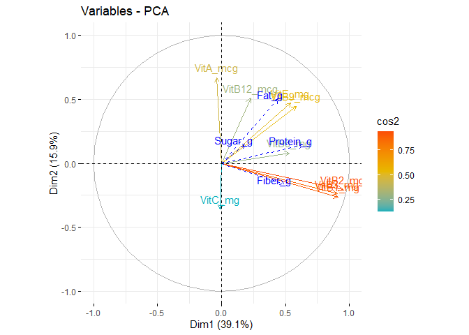

```r
fviz_pca_var(pca.plats22,axes = c(1,2),col.var = "cos2",
             gradient.cols = c("#00AFBB", "#E7B800", "#FC4E07"))
```

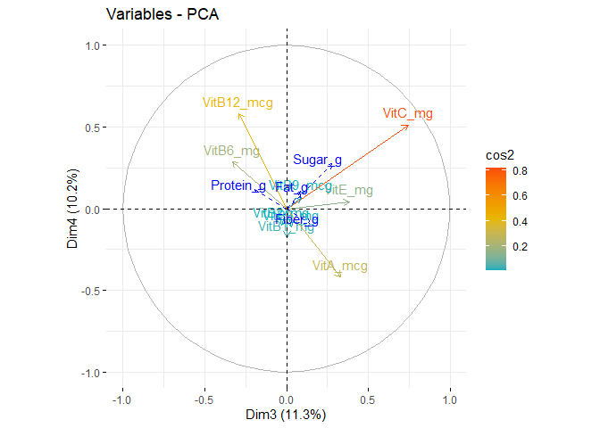

```r
fviz_pca_var(pca.plats22,axes = c(3,4),col.var = "cos2",
             gradient.cols = c("#00AFBB", "#E7B800", "#FC4E07"))
```

*Axe 1 :*

Sur le premier plan factoriel et en observant les variables corrélées au 2 premières composantes, on remarque que ce sont les variables correspondant aux compositions en vitamines B1, B2 et B3 qui sont les plus corrélées positivement. Les variables Vitamine E et B9 et la variable supplémentaire protéine sont également positivement corrélées avec la première composante, mais dans une plus faible mesure.

*Axe 2 :*

Nous pouvons voir que les variables ayant une forte coordonnée positive sur l’axe 2 sont les variables VitA et VitB12 tout comme la variable supplémentaire Fat. Ainsi, les plats ayant une forte coordonnée positive sur l’axe 2 sont plus gras, et ont une forte composition en vitamine A et B12.

*Axe 3 et 4 :*

Les axes 3 et 4 semblent expliqués en grande partie par les variables de vitamine C et de vitamine B12. De fortes coordonnées sur l’axe 3 correspondra à de fortes valeurs sur la variables Vitamine C et de fortes coordonnées sur l’axe 4 traduira un forte composition en vitamine B12.

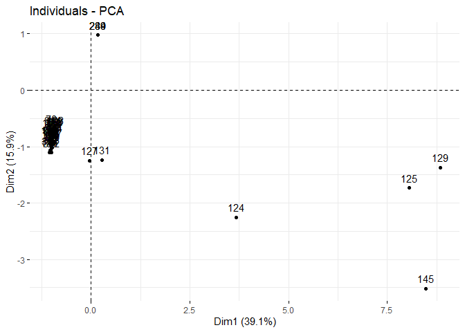

```r
fviz_pca_ind(pca.plats22,axes =c(1,2), select.ind = list(name=NULL, cos2 = 0.85, contrib = NULL))
```

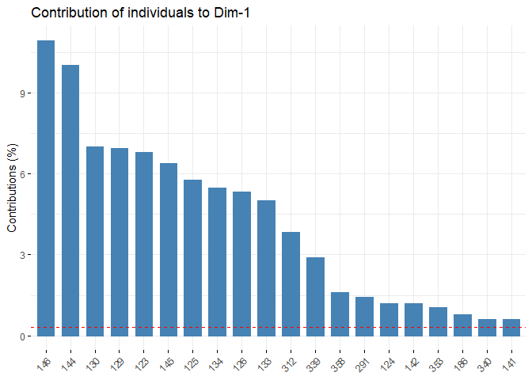

```r
fviz_contrib(pca.plats22,choice="ind",axes = 1, sortcontrib = "desc", top = 20)
```

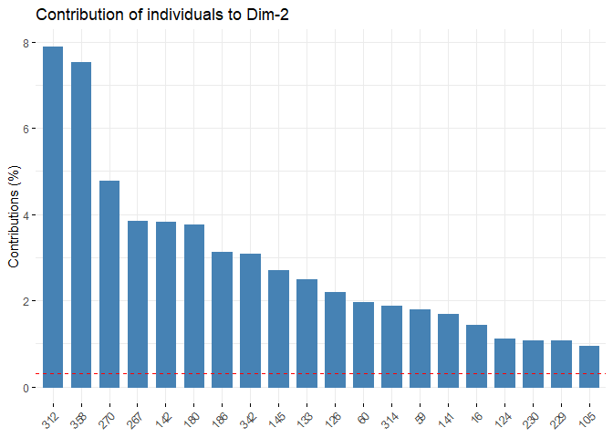

```r
fviz_contrib(pca.plats22,choice="ind",axes = 2, sortcontrib = "desc", top = 20)
```

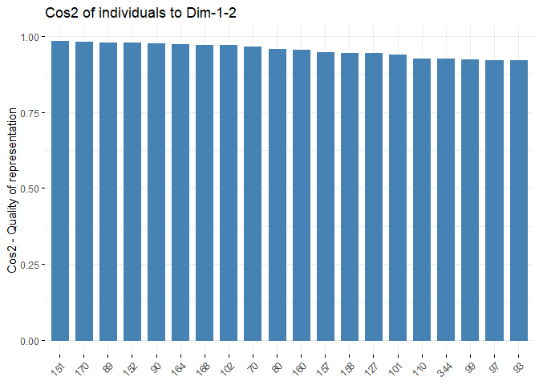

```r
fviz_cos2(pca.plats22,choice="ind",axes = c(1,2), sort.val = "desc", top = 20)
```

Sur le premier plan factoriel, les individus projetés les plus à droite seront les plats comprenant le plus de vitamines B1, B2 et B3 ainsi que les plats plus protéinés et fibreux. On peut par exemple noter les plats 144 et 145, des plats fruités et/ou protéinés et bien représentés sur le plan.

```r
pca.plats22$ind$cos2[c(144, 145),]
```

```
##         Dim.1       Dim.2      Dim.3      Dim.4       Dim.5
## 144 0.7564658 0.008698579 0.00193300 0.01561175 0.005523184
## 145 0.7289487 0.125519407 0.01701484 0.03438235 0.009007830
```

Aussi les plats les plus en bas (coordonnées faibles sur l’axe 2) sont les plats faibles en graisse et en vitamine A. Par ailleurs, ce sont aussi les plats les plus concentrés en vitamine C comme le plat 124.

```r
pca.plats22$ind$cos2[124,]
```

```
##       Dim.1       Dim.2       Dim.3       Dim.4       Dim.5
## 0.640931951 0.240693028 0.084341629 0.002413520 0.000232863
```

Nous avons pu analysé cet individu, puisqu’il est bien représenté sur le plan.

Enfin, les plats comme le plat 274 (avec de fortes coordonnées sur les 2 axes du plan) correspondent aux plats inactfs avec une forte composition en vitamine B6, B12; une très faible composition en vitamine C mais une composition en graisse non négligeable.

Enfin les plats bien représentés situés à des coordonnées faibles sur les 2 axes correspondent aux plats peu gras, peu protéinés et peu vitaminés. L’individu 108 bien représenté en est un exemple. En regardant la base de données, il correspond à un plat à base de pomme et de mûre, peu protéiné donc.

```r
pca.plats22$ind$cos2[108,]
```

```
##        Dim.1        Dim.2        Dim.3        Dim.4        Dim.5
## 0.5580728114 0.3421062665 0.0234894023 0.0003501462 0.0001126646
```

# D/ Analyse des correspondance multiples sur variables catégorisées.

### a) Catégorisation des variables

Les variables sont désormais toutes catégorielles et nous pouvons donc réaliser une Analyse en Correspondance Multiples sur le nouveau jeu de données.

### b) ACM avec les mesures de vitamines

On crée une nouvelle base de données composée uniquement des 13 variables catégorielles.

```r
plats_cat <- subset(plats,select=-c(1:13))
acm_plats <- MCA(plats_cat[1:13], quali.sup = c(1, 10, 11, 12), graph = F)
```

*Valeurs propres :*

On trouve les valeurs propres suivantes:

```r
acm_plats$eig
```

```
##        eigenvalue percentage of variance cumulative percentage of variance
## dim 1  0.60305146             30.1525730                          30.15257
## dim 2  0.42165261             21.0826304                          51.23520
## dim 3  0.13298537              6.6492685                          57.88447
## dim 4  0.11808176              5.9040881                          63.78856
## dim 5  0.11437789              5.7188946                          69.50745
## dim 6  0.10175555              5.0877776                          74.59523
## dim 7  0.07843884              3.9219418                          78.51717
## dim 8  0.06914761              3.4573807                          81.97455
## dim 9  0.05958836              2.9794178                          84.95397
## dim 10 0.05102765              2.5513824                          87.50535
## dim 11 0.04842185              2.4210923                          89.92645
## dim 12 0.04397057              2.1985283                          92.12498
## dim 13 0.03946793              1.9733964                          94.09837
## dim 14 0.03303576              1.6517880                          95.75016
## dim 15 0.03094079              1.5470396                          97.29720
## dim 16 0.02390348              1.1951741                          98.49237
## dim 17 0.02010234              1.0051172                          99.49749
## dim 18 0.01005018              0.5025092                         100.00000
```

*Coordonneés des variables et qualité de projection :*

```r
acm_plats$var$coord
```

```
##                        Dim 1       Dim 2       Dim 3       Dim 4       Dim 5
## Cat_VitA_Faible   -0.2581598  0.92720639  0.14384926  0.74194702 -0.76751524
## Cat_VitA_Moyen    -0.4258702 -0.50103018 -0.03648687  0.01842267  0.49916193
## Cat_VitA_Fort      1.1316134 -0.09543024 -0.09541914 -0.89599200 -0.08601474
## Cat_VitB6_Faible  -0.6928826  0.59505584 -0.26724266  0.34361763  1.00504315
## Cat_VitB6_Moyen   -0.3330419 -0.48633386  0.13734224 -0.32992281 -0.59005873
## Cat_VitB6_Fort     1.4183442  0.23221856  0.04794617  0.22627044 -0.04221688
## Cat_VitB12_Faible -0.4722344  0.54581223  0.26570614 -0.14988572 -0.20810849
## Cat_VitB12_Moyen  -0.2944137 -1.05377953 -0.54476301  0.53632103  0.16484911
## Cat_VitB12_Fort    1.2667224 -0.03869537  0.01365075 -0.24186530  0.25701659
## Cat_VitC_Faible   -0.2996807 -0.25982379  1.47688232 -0.17413892  0.40360500
## Cat_VitC_Moyen    -0.3305736 -0.26367139 -0.64626517  0.29102846 -0.34637318
## Cat_VitC_Fort      0.9671442  0.79289768 -0.24076211 -0.39887971  0.27183928
## Cat_VitE_Faible   -0.5301070  0.66988836  0.53003918  0.75492576  0.14216103
## Cat_VitE_Moyen    -0.3973948 -0.28955947 -0.04038423 -0.39410431 -0.25405480
## Cat_VitE_Fort      1.3546695 -0.09280917 -0.45936669  0.03403078  0.37417214
## Cat_VitB9_Faible  -0.6348459  1.08867385  0.10805559 -0.20534532  0.20706611
## Cat_VitB9_Moyen   -0.3553481 -0.56172436  0.07387084  0.19879447 -0.15395346
## Cat_VitB9_Fort     1.4284256 -0.02659345 -0.27082796 -0.18707125  0.09241773
## Cat_VitB3_Faible  -0.7548422  1.22698861 -0.28656533 -0.04369301  0.10378440
## Cat_VitB3_Moyen   -0.3759751 -0.73837185 -0.01305228 -0.16833842  0.02819326
## Cat_VitB3_Fort     1.4985292  0.23352714  0.31238302  0.37667011 -0.15955128
## Cat_VitB2_Faible  -0.7387568  1.19420517 -0.15356966 -0.43087648 -0.03370230
## Cat_VitB2_Moyen   -0.3630586 -0.68493051 -0.05315521  0.07167521  0.10105122
## Cat_VitB2_Fort     1.4568947  0.16060244  0.25871184  0.28910134 -0.16617922
## Cat_Prot_Faible   -0.7171097  1.26516958 -0.38646638 -0.28188969 -0.08503730
## Cat_Prot_Moyen    -0.3594837 -0.73684955  0.12789162 -0.01966095  0.09870507
## Cat_Prot_Fort      1.4321062  0.17033480  0.13914624  0.32366112 -0.10818434
```

```r
acm_plats$var$cos2
```

```
##                        Dim 1        Dim 2        Dim 3        Dim 4
## Cat_VitA_Faible   0.02614592 0.3372715104 8.117870e-03 0.2159596516
## Cat_VitA_Moyen    0.16418346 0.2272493330 1.205169e-03 0.0003072416
## Cat_VitA_Fort     0.41127114 0.0029248537 2.924173e-03 0.2578341096
## Cat_VitB6_Faible  0.19092234 0.1408162909 2.840201e-02 0.0469557020
## Cat_VitB6_Moyen   0.09712411 0.2071087289 1.651725e-02 0.0953134289
## Cat_VitB6_Fort    0.66563615 0.0178429829 7.606439e-04 0.0169406183
## Cat_VitB12_Faible 0.22548312 0.3012211092 7.138420e-02 0.0227153494
## Cat_VitB12_Moyen  0.02910637 0.3728821700 9.965230e-02 0.0965876851
## Cat_VitB12_Fort   0.52310669 0.0004881411 6.074915e-05 0.0190710458
## Cat_VitC_Faible   0.03104904 0.0233393359 7.540887e-01 0.0104838882
## Cat_VitC_Moyen    0.10689029 0.0680029818 4.085295e-01 0.0828462511
## Cat_VitC_Fort     0.30949671 0.2080213444 1.918006e-02 0.0526450454
## Cat_VitE_Faible   0.09436244 0.1506874089 9.433830e-02 0.1913729694
## Cat_VitE_Moyen    0.15967732 0.0847762967 1.649007e-03 0.1570439648
## Cat_VitE_Fort     0.59826568 0.0028080781 6.879333e-02 0.0003775472
## Cat_VitB9_Faible  0.14339996 0.4217042005 4.154385e-03 0.0150031334
## Cat_VitB9_Moyen   0.12488470 0.3120668515 5.396935e-03 0.0390849625
## Cat_VitB9_Fort    0.64550829 0.0002237361 2.320457e-02 0.0110713514
## Cat_VitB3_Faible  0.19133060 0.5055372554 2.757525e-02 0.0006410561
## Cat_VitB3_Moyen   0.13980389 0.5392018618 1.684898e-04 0.0280264203
## Cat_VitB3_Fort    0.75405409 0.0183124657 3.276777e-02 0.0476424869
## Cat_VitB2_Faible  0.18326313 0.4788836318 7.919230e-03 0.0623415628
## Cat_VitB2_Moyen   0.13036306 0.4639745359 2.794428e-03 0.0050808817
## Cat_VitB2_Fort    0.71273555 0.0086611666 2.247526e-02 0.0280654695
## Cat_Prot_Faible   0.17522467 0.5454080545 5.089176e-02 0.0270758716
## Cat_Prot_Moyen    0.12640384 0.5310795545 1.599875e-02 0.0003781038
## Cat_Prot_Fort     0.68868809 0.0097426902 6.501522e-03 0.0351765434
##                          Dim 5
## Cat_VitA_Faible   0.2311004754
## Cat_VitA_Moyen    0.2255577502
## Cat_VitA_Fort     0.0023761721
## Cat_VitB6_Faible  0.4017046689
## Cat_VitB6_Moyen   0.3048736400
## Cat_VitB6_Fort    0.0005897201
## Cat_VitB12_Faible 0.0437903566
## Cat_VitB12_Moyen  0.0091252612
## Cat_VitB12_Fort   0.0215352378
## Cat_VitC_Faible   0.0563175483
## Cat_VitC_Moyen    0.1173519908
## Cat_VitC_Fort     0.0244510783
## Cat_VitE_Faible   0.0067863023
## Cat_VitE_Moyen    0.0652609947
## Cat_VitE_Fort     0.0456425862
## Cat_VitB9_Faible  0.0152556387
## Cat_VitB9_Moyen   0.0234412098
## Cat_VitB9_Fort    0.0027020733
## Cat_VitB3_Faible  0.0036168980
## Cat_VitB3_Moyen   0.0007861251
## Cat_VitB3_Fort    0.0085481613
## Cat_VitB2_Faible  0.0003814093
## Cat_VitB2_Moyen   0.0100991355
## Cat_VitB2_Fort    0.0092731128
## Cat_Prot_Faible   0.0024640131
## Cat_Prot_Moyen    0.0095297352
## Cat_Prot_Fort     0.0039300757
```

```r
summary(acm_plats)
```

```
##
## Call:
## MCA(X = plats_cat[1:13], quali.sup = c(1, 10, 11, 12), graph = F)
##
##
## Eigenvalues
##                        Dim.1   Dim.2   Dim.3   Dim.4   Dim.5   Dim.6   Dim.7
## Variance               0.603   0.422   0.133   0.118   0.114   0.102   0.078
## % of var.             30.153  21.083   6.649   5.904   5.719   5.088   3.922
## Cumulative % of var.  30.153  51.235  57.884  63.789  69.507  74.595  78.517
##                        Dim.8   Dim.9  Dim.10  Dim.11  Dim.12  Dim.13  Dim.14
## Variance               0.069   0.060   0.051   0.048   0.044   0.039   0.033
## % of var.              3.457   2.979   2.551   2.421   2.199   1.973   1.652
## Cumulative % of var.  81.975  84.954  87.505  89.926  92.125  94.098  95.750
##                       Dim.15  Dim.16  Dim.17  Dim.18
## Variance               0.031   0.024   0.020   0.010
## % of var.              1.547   1.195   1.005   0.503
## Cumulative % of var.  97.297  98.492  99.497 100.000
##
## Individuals (the 10 first)
##                      Dim.1    ctr   cos2    Dim.2    ctr   cos2    Dim.3    ctr
## 1                 | -0.734  0.247  0.223 |  1.240  1.008  0.637 | -0.211  0.092
## 2                 | -0.011  0.000  0.000 | -0.151  0.015  0.013 | -0.198  0.081
## 3                 | -0.011  0.000  0.000 | -0.151  0.015  0.013 | -0.198  0.081
## 4                 |  0.313  0.045  0.047 | -0.169  0.019  0.014 |  0.671  0.936
## 5                 |  0.488  0.109  0.113 | -0.031  0.001  0.000 | -0.051  0.005
## 6                 |  0.003  0.000  0.000 |  0.169  0.019  0.016 | -0.015  0.000
## 7                 |  0.271  0.034  0.036 |  0.335  0.074  0.055 |  0.084  0.015
## 8                 |  0.222  0.023  0.020 |  0.298  0.058  0.037 |  0.559  0.648
## 9                 |  0.500  0.115  0.108 | -0.008  0.000  0.000 |  0.600  0.747
## 10                |  0.500  0.115  0.108 | -0.008  0.000  0.000 |  0.600  0.747
##                     cos2
## 1                  0.018 |
## 2                  0.022 |
## 3                  0.022 |
## 4                  0.218 |
## 5                  0.001 |
## 6                  0.000 |
## 7                  0.004 |
## 8                  0.129 |
```

[output cut: 54 more lines]

```
## Cat_Sugar_Fort      0.033  -3.451 |
## Cat_VitB1_Faible    0.003  -1.033 |
## Cat_VitB1_Moyen     0.006  -1.422 |
## Cat_VitB1_Fort      0.020   2.673 |
## Cat_Fat_Faible      0.026  -3.093 |
## Cat_Fat_Moyen       0.053   4.361 |
## Cat_Fat_Fort        0.010  -1.865 |
## Cat_Fiber_Faible    0.090  -5.685 |
##
## Supplementary categorical variables (eta2)
##                     Dim.1 Dim.2 Dim.3
## Cat_Sugar         | 0.378 0.018 0.155 |
## Cat_VitB1         | 0.726 0.340 0.020 |
## Cat_Fat           | 0.578 0.466 0.054 |
## Cat_Fiber         | 0.130 0.046 0.107 |
```

Les Variables correspondant aux compositions en protéine A, B et E sont assez bien représentées sur le premier plan factoriel, contrairement à la variable représentant la protéine C.

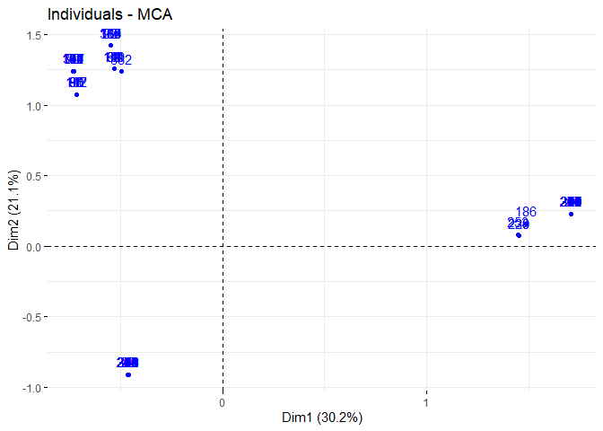

```r
fviz_mca_ind(acm_plats, axes = c(1,2), select.ind = list(name=NULL, cos2 = 0.7 , contrib = NULL))
```

Parmi les individus les mieux représentés sur le premier plan facoriel, le plat 253 a des coordonnées très élevées sur l’axe 1. C’est alors un plat gras et protéiné, avec de fortes compositions en vitamines A, B et E. En regardant dans la base de données, on trouveque c’est un plat protéinié à base de poudre de fer.

A l’inverse, l’individu 160 (en haut à gauche) aura quant à lui un faible taux de protéine, peu de gras, et donc de faibles compositions en vitamines A, B et E mais forte en vitamine C. En observant le jeu de données initial, il s’agit d’un dessert (peu protéiné) à base de pêche, résultat cohérent avec ce que nous avons annoncé ci dessus.

### c) Calcul de l’inertie totale.

On retrouve l’inertie totale en faisant la somme des valeurs propres:

```r
sum(acm_plats$eig[,1])
```

```
## [1] 2
```

On trouve bien le même résultat que lorsque l’on fait la sommes des valeurs propres.

### d) Graphe des modalités

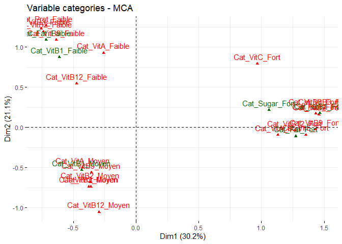

```r
fviz_mca_var(acm_plats, axes = c(1,2), select.var = list(name = NULL, cos2 = 0.35, contrib = NULL))
```

En recherchant, les vitamines A et B sont en grande partie trouvées dans les aliments d’origine animale (foie, abats, fruits de mer, poisson, …).

Ces aliments sont aussi connus pour être protéinés et gras. La proximité entre ces points-modalités est alors logique, oÃ¹ un plat gras et protéiné aura probablement une forte composition de ces vitamines. Dans la même idée, un plat avec une forte composition en vitamine A et B sera davantage susceptible d’être gras et protéiné.

De plus, le point modalité indiquant une forte composition en vitamine E est non loin du point modalité correspondant à un taux de gras élevé. La vitamine E se retrouve dans les huiles, les avocats ou encore le beurre. Ainsi, il est logique qu’un plat fort en vitamine E soit gras et inversement.

Enfin, le premier plan factoriel nous indique qu’un plat gras sera sans doute davantage protéiné qu’un plat non gras, résultat dépendant de la composition en vitamines A, B et E.